# FPP Ch 8

# Qn 5

```r
library(data.table)
library(fpp3)
```

```r
ec_can <- global_economy %>%
  filter(Country == "Canada")

ec_can %>% autoplot(Exports)

can_fit <- ec_can %>%
  model( ETS(Exports ~ error("A") + trend("N") + season("N")))
```

```r
can_fc <- can_fit %>%
  forecast(h=10)

can_fc %>% autoplot() +
  autolayer(ec_can, Exports)

# environmentName(environment(accuracy))
accuracy(can_fit)
```

5d) The model with a trend is not significantly better than the model without. likely because there was a significant spike in exports in 2000 and it goes back down to the long term average after.

```r
can_fit <- ec_can %>%
  model(
    ANN = ETS(Exports ~ error("A") + trend("N") + season("N")),
    AAN = ETS(Exports ~ error("A") + trend("A") + season("N"))
  )

accuracy(can_fit)
```

5e) the forecast for AAN with the negative trend seems incorrect. it puts too much weight on the drop since the 2000 spike, instead of the recent points which show a clear increasing trend.

```r
can_fc <- can_fit %>%
  forecast(h=10)

head(can_fc)

can_fc %>% autoplot()

can_fc %>% ggplot(aes(x = Year)) +
  geom_line(aes(y = .mean, color = .model)) +
  geom_line(aes(x = Year, y = Exports), data = ec_can, )
```

5f) Forecast variance of (A,N,N) is $\sigma_h^2 = \sigma^2 [1 + \alpha^2(h-1)]$

```r
can_fit %>% components() # gets you the level slope components of ETS
can_fit %>% tidy() # get model coefficients
can_fit %>% fitted() # get only fitted values, this is less useful
can_fit %>% augment() # get exports and fitted values and residuals in the same dataset

ec_can

accuracy(can_fit)

accuracy(can_fit)$RMSE[1]
```

# Qn 6

Forecast the Chinese GDP from the `global_economy` data set using an ETS model. Experiment with the various options in the `ETS()` function to see how much the forecasts change with damped trend, or with a Box-Cox transformation. Try to develop an intuition of what each is doing to the forecasts.

```r
china <- global_economy %>%
  filter(Country == "China")

china %>% autoplot(GDP)

china_fit <- china %>%
  model(
    "holt" = ETS(GDP ~ error("A") + trend("A") + season("N")),
    "damped" = ETS(GDP ~ error("A") + trend("Ad") + season("N"))
    # "mult_damped" = ETS(GDP ~ error("A") + trend("M") + season("N")) #multiplicative trend does not exist
  )

china_fc <- china_fit %>%
  forecast(h=20)

china_fc

china_fc %>%
  autoplot() +
  autolayer(china, GDP)
```

Apply box-cox transformation

```r
#I don't know what this "features" funciton do but it seems useful

lambda <- china %>%
  features(GDP, features = guerrero) %>%
  pull(lambda_guerrero)

china %>% autoplot(box_cox(GDP, lambda))

# china_fit

# supposedly, applying a transofmration within a model will automatically back transform it. How do we confirm?

china_fit2 <- china %>%
  model(
    "boxcox" = ETS(box_cox(GDP, lambda) ~ error("A") + trend("Ad") + season("N"))
  )

#combine this into the original mable china_fit
#I don't know if there's an easier way to combine two mables? but this works :/

merge(china_fit, china_fit2)

china_fit_tb <- china_fit %>%
  merge(china_fit2)

china_fit_models <- names(china_fit_tb)[-1]

# typeof(china_fit_models)

china_fit_comb <- china_fit_tb %>%
  mable(key = Country, model = all_of(china_fit_models))

china_fit_comb

#plot results

china_fit_comb %>%
  forecast(h=10) %>%
  autoplot(china, level = NULL)

#unclear what's going on with this transformation if not dampened. The forecast just shoots off into infinity.
```

# Qn 7

```r
aus_production %>% autoplot(Gas)

aus_fit <- aus_production %>%
  model(
    "AAdM" = ETS(Gas ~ error("A") + trend("Ad") + season("M"))
  )

aus_fit

#why does this take so long to run?
aus_fc <- aus_fit %>%
  forecast(h = "3 years")

augment(aus_fit)
aus_fc_hilo <- aus_fc %>%
  hilo() %>%
  unpack_hilo(`95%`)
aus_fc_hilo # unpack_hilo() will unpack this object

# forecast plot
aus_fc %>%
  autoplot(aus_production)

# historical actual vs expected
augment(aus_fit) %>%
  ggplot(aes(x = Quarter))+
  geom_line(aes(y = .fitted)) +
  geom_point(data = aus_production, aes(y = Gas))

# add damped trend and compare RMSE
# let the program decide on the best model specification
```

# Qn 8

```r
aus_retail
```

| State | Industry | Series ID | Month | Turnover |
| --- | --- | --- | --- | --- |
| Australian Capital Territory | Cafes, restaurants and catering services | A3349849A | 1982 Apr | 4.4 |
| Australian Capital Territory | Cafes, restaurants and catering services | A3349849A | 1982 May | 3.4 |
| Australian Capital Territory | Cafes, restaurants and catering services | A3349849A | 1982 Jun | 3.6 |
| Australian Capital Territory | Cafes, restaurants and catering services | A3349849A | 1982 Jul | 4.0 |
| Australian Capital Territory | Cafes, restaurants and catering services | A3349849A | 1982 Aug | 3.6 |
| Australian Capital Territory | Cafes, restaurants and catering services | A3349849A | 1982 Sep | 4.2 |
| Australian Capital Territory | Cafes, restaurants and catering services | A3349849A | 1982 Oct | 4.8 |
| Australian Capital Territory | Cafes, restaurants and catering services | A3349849A | 1982 Nov | 5.4 |
| Australian Capital Territory | Cafes, restaurants and catering services | A3349849A | 1982 Dec | 6.9 |
| Australian Capital Territory | Cafes, restaurants and catering services | A3349849A | 1983 Jan | 3.8 |

[output cut: 990 more lines]

```r
# ?aus_retail

set.seed(123456789)
myseries <- aus_retail %>%
  filter(`Series ID` == sample(aus_retail$`Series ID`,1))

myseries
```

| State | Industry | Series ID | Month | Turnover |
| --- | --- | --- | --- | --- |
| Tasmania | Hardware, building and garden supplies retailing | A3349590A | 1982 Apr | 2.4 |
| Tasmania | Hardware, building and garden supplies retailing | A3349590A | 1982 May | 2.5 |
| Tasmania | Hardware, building and garden supplies retailing | A3349590A | 1982 Jun | 2.1 |
| Tasmania | Hardware, building and garden supplies retailing | A3349590A | 1982 Jul | 2.7 |
| Tasmania | Hardware, building and garden supplies retailing | A3349590A | 1982 Aug | 2.9 |
| Tasmania | Hardware, building and garden supplies retailing | A3349590A | 1982 Sep | 2.6 |
| Tasmania | Hardware, building and garden supplies retailing | A3349590A | 1982 Oct | 2.6 |
| Tasmania | Hardware, building and garden supplies retailing | A3349590A | 1982 Nov | 3.2 |
| Tasmania | Hardware, building and garden supplies retailing | A3349590A | 1982 Dec | 6.0 |
| Tasmania | Hardware, building and garden supplies retailing | A3349590A | 1983 Jan | 2.6 |

[output cut: 431 more lines]

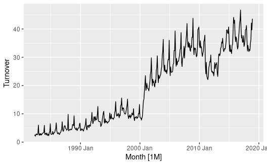

```r
myseries %>%
  autoplot(Turnover)
```

Multiplicative seasonality is necessary because the seasonal variations vary in magnitude depending on the level

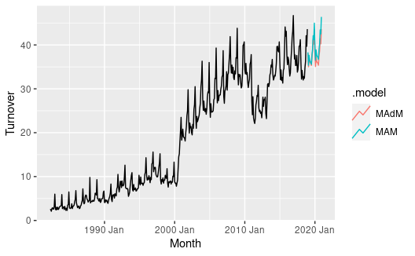

```r
#we should be using only the training set here

my_fit <- myseries %>%
  model(
        "MAM" = ETS(Turnover ~ error("M") + trend("A") + season("M")),
        "MAdM" = ETS(Turnover ~ error("M") + trend("Ad") + season("M")))

my_fc <- my_fit %>%
  forecast(h = "2 years")

my_fc %>% autoplot(myseries, level = NULL)
```

I’m unclear about whether we should always use multiplicative seasonality with multiplicative errors?

```r
myseries_train <- myseries %>%
  filter(year(Month) < 2011)

myseries_test <- myseries %>%
  filter(year(Month) >= 2011)
```

```r
modelled <- stretch %>%
    model(
        "MAM" = ETS(Turnover ~ error("M") + trend("A") + season("M")),
        "MAdM" = ETS(Turnover ~ error("M") + trend("Ad") + season("M"))
    )
modelled <- stretch %>%
    model(
        "MAM" = ETS(Turnover ~ error("M") + trend("A") + season("M")),
        "MAdM" = ETS(Turnover ~ error("M") + trend("Ad") + season("M"))
    )
```

```r
components(my_fit) %>%
  filter(.model == "MAdM") %>%
  autoplot()
```

[output not shown]

Looks like the slope parameter might not be needed? The remainder does not look like white noise it significantly goes down over time.

At this point, we could try additive errors? Though that does not change the point forecasts.

| .model | State | Industry | .type | ME | RMSE | MAE | MPE | MAPE | MASE | RMSSE | ACF1 |
| --- | --- | --- | --- | --- | --- | --- | --- | --- | --- | --- | --- |
| MAdM | Tasmania | Hardware, building and garden supplies retailing | Test | 2.1812032 | 5.540263 | 5.080222 | 4.198215 | 15.48194 | NaN | NaN | 0.9236993 |
| MAM | Tasmania | Hardware, building and garden supplies retailing | Test | -2.2649783 | 4.284066 | 3.317264 | -8.442058 | 11.19678 | NaN | NaN | 0.8346418 |
| SNAIVE | Tasmania | Hardware, building and garden supplies retailing | Test | -0.5447917 | 5.473678 | 4.536458 | -4.610440 | 14.93887 | NaN | NaN | 0.9220099 |

# Qn 9

| State | Industry | .model | Month | Turnover | .mean |
| --- | --- | --- | --- | --- | --- |
| Tasmania | Hardware, building and garden supplies retailing | MAM | 2011 Jan |  | 31.69417 |
| Tasmania | Hardware, building and garden supplies retailing | MAM | 2011 Feb |  | 29.19000 |
| Tasmania | Hardware, building and garden supplies retailing | MAM | 2011 Mar |  | 31.23229 |
| Tasmania | Hardware, building and garden supplies retailing | MAM | 2011 Apr |  | 29.60285 |
| Tasmania | Hardware, building and garden supplies retailing | MAM | 2011 May |  | 29.95359 |
| Tasmania | Hardware, building and garden supplies retailing | MAM | 2011 Jun |  | 29.12354 |
| Tasmania | Hardware, building and garden supplies retailing | MAM | 2011 Jul |  | 28.28562 |
| Tasmania | Hardware, building and garden supplies retailing | MAM | 2011 Aug |  | 30.05814 |
| Tasmania | Hardware, building and garden supplies retailing | MAM | 2011 Sep |  | 31.15583 |
| Tasmania | Hardware, building and garden supplies retailing | MAM | 2011 Oct |  | 34.84390 |

[output cut: 86 more lines]

```
Plot variable not specified, automatically selected `.vars = Turnover`
```

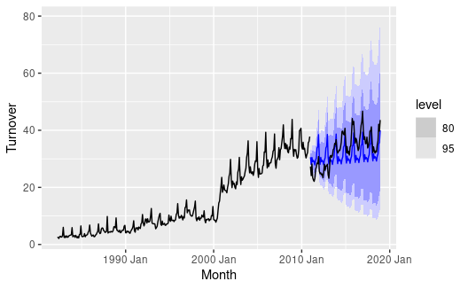

```r
dcmp_fc %>%
  autoplot(myseries_train) +
  autolayer(myseries_test)
```

```
Plot variable not specified, automatically selected `.vars = Turnover`
```

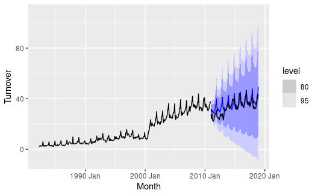

```r
my_fc_test %>%
  filter(.model == "MAM") %>%
  autoplot(myseries_train) +
  autolayer(myseries_test)
```

# Qn 10

```
Plot variable not specified, automatically selected `.vars = Trips`
```

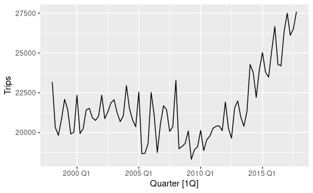

```r
aus_tour %>% autoplot()
```

The trips stayed flat until 2009, dropping during the GFS, then steadily increases

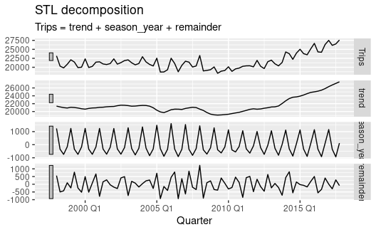

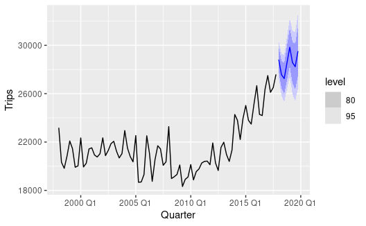

```r
tour_fit1 <- aus_tour %>%
  model(
    "damped" = decomposition_model(
      STL(Trips),
      ETS(season_adjust ~ error("A") + trend("Ad") + season("N"))
    ),
    "Holt" = decomposition_model(
      STL(Trips),
      ETS(season_adjust ~ error("A") + trend("A") + season("N"))
    )
  )

tour_fc <- tour_fit1 %>%
  forecast(h = "2 years")

tour_fc %>%
  filter(.model == "damped") %>%
  autoplot(aus_tour)
```

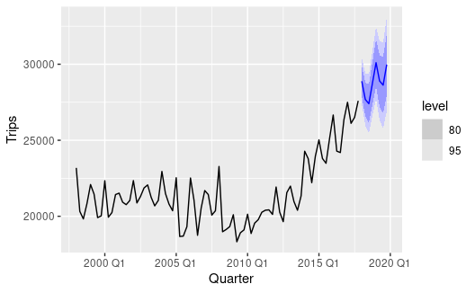

```r
tour_fc %>%
  filter(.model == "Holt") %>%
  autoplot(aus_tour)
```

| .model | .type | ME | RMSE | MAE | MPE | MAPE | MASE | RMSSE | ACF1 |
| --- | --- | --- | --- | --- | --- | --- | --- | --- | --- |
| ETS(Trips) | Training | 105.46553 | 793.6695 | 604.1089 | 0.3787233 | 2.857009 | 0.6363847 | 0.6534916 | -0.001509254 |
| damped | Training | 102.97404 | 763.3689 | 576.1664 | 0.3671466 | 2.722076 | 0.6069494 | 0.6285427 | -0.017373440 |
| Holt | Training | 99.67145 | 762.6375 | 573.7166 | 0.3586624 | 2.714016 | 0.6043686 | 0.6279404 | -0.018154028 |

The model with the lowest errors are the decomposition with Holt, though it comes pretty close

As for the forecasts, I like the damped approach because we do not know why the increase happened and whether or not it should continue.

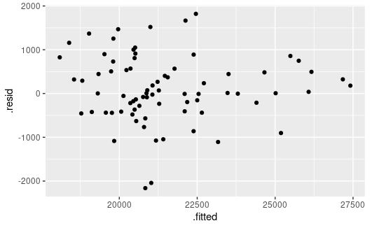

# Qn 11

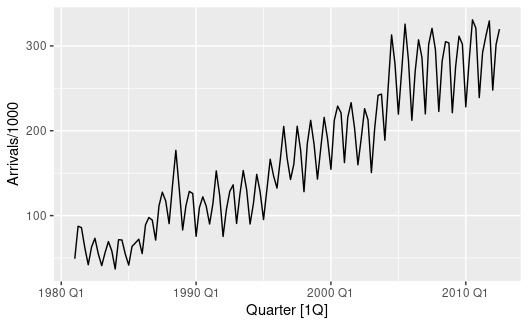

the visits are steadily increasing over time, with larger seasonal variations at a higher level

| Quarter |
| --- |
| 2012 Q3 |
| 2012 Q2 |
| 2012 Q1 |
| 2011 Q4 |
| 2011 Q3 |
| 2011 Q2 |
| 2011 Q1 |
| 2010 Q4 |
| 2010 Q3 |
| 2010 Q2 |

[output cut: 117 more lines]